[figure not shown]

# Send Them Back: Restore Britain's Leaders Inside Europe's Remigration Network

Rupert Lowe signed it. His spokesman, his policy fellow and his best-known activist are working for it. The Telegraph showed half the picture. Here is the rest, in their own words.

By Steve English, Independent British writer and editor · 3 November 2026

- Rupert Lowe has signed the Save Europe Act, a Europe-wide remigration campaign co-founded by Martin Sellner, an Austrian activist banned from Britain.
- The campaign's own account signs off its posts "Send them back!" and runs national speakers, national coordinators and a 15-stop tour.
- Restore's spokesman Charlie Downes wants the "present regime" gone and its "apparatchiks imprisoned". Its senior policy fellow writes of the "ethnocide of Britons".
- Restore activist Lucy White, Britain's self-styled Save Europe Act representative, was posting from Paris the morning after Sellner was turned back at the French border.
- At around 4 per cent and flat for six months, Restore cannot win. It can split the vote.

**PURPOSE:** To set out, from the posts and documents of the people involved, how Restore Britain's leadership is tied into the Europe-wide remigration campaign, and what that means for voters who want immigration brought under control.

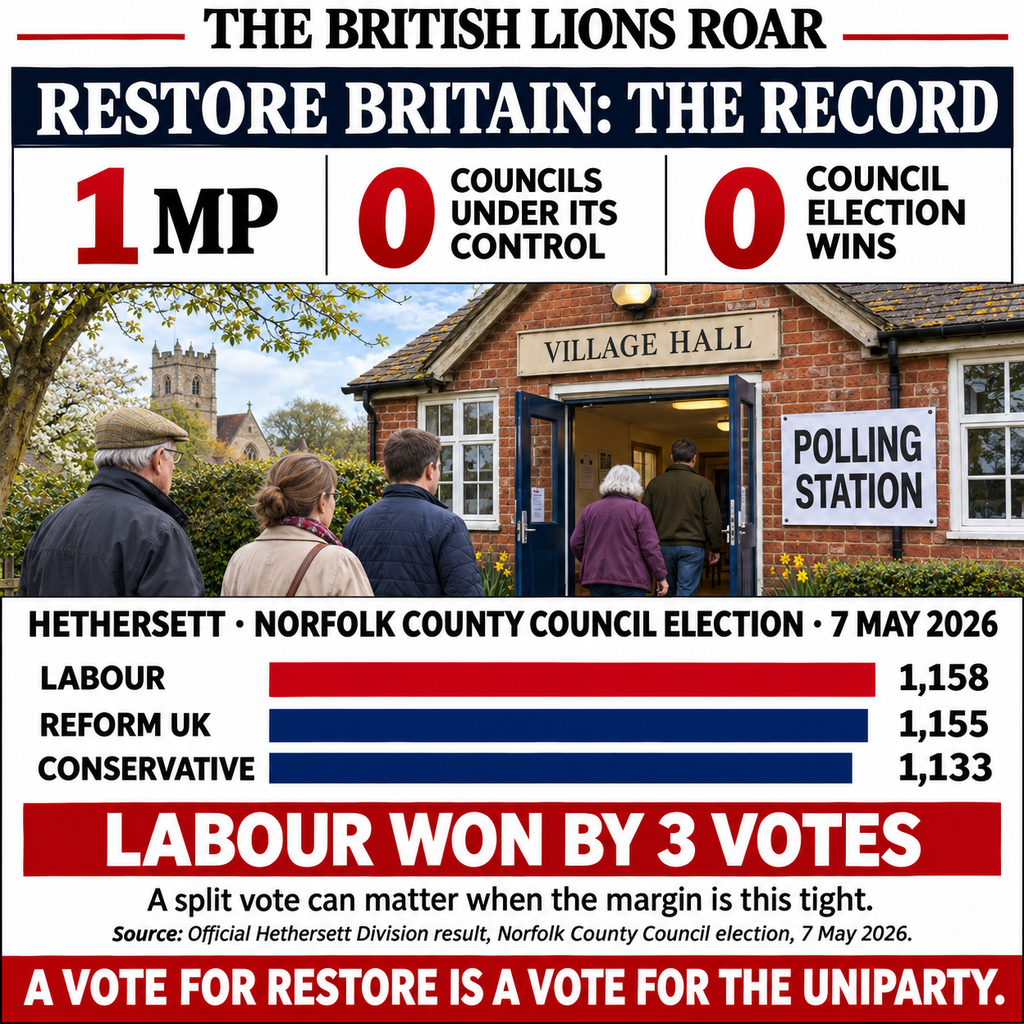

Hethersett is an example of how close a council result can be; the graphic sets that narrow margin alongside Restore Britain’s current record.

Rupert Lowe needed his passport for this interview. His host, the Dutch activist Eva Vlaardingerbroek, can no longer come to Britain without a visa. In January the Home Office revoked her electronic travel authorisation on the grounds that her presence was not conducive to the public good. So the MP for Great Yarmouth flew to Italy to sit down with her.

"Millions have to go," he told her, according to the Telegraph's report of the interview. He has signed her campaign, the Save Europe Act, and his photograph sits on its website.

None of this was a first meeting of minds. When her travel authorisation was pulled in January, Lowe went straight to bat for her.

> I have formally questioned the Home Office on why Eva Vlaardingerbroek has been denied entry to Britain, and requesting that they reverse their appalling decision.  
> I will keep you all updated with their response.

> — Rupert Lowe MP (@RupertLowe10) [January 15, 2026](https://x.com/RupertLowe10/status/2011724428418433261)

## What the Save Europe Act actually is

On paper it is a petition. It calls for an EU-wide halt to immigration and for the expulsion of migrants, legal as well as illegal, and it is closing in on its target of one million signatures. It was co-founded by Vlaardingerbroek and Martin Sellner, the Austrian activist barred from Britain on security grounds since 2019.

Its own account leaves no room for a softer reading. This is how it signed off a rally post last week:

> 🛡️Do you get it NOW?  
> This was the 15th European Shield Tour stop in Bavaria, Germany 🇩🇪!  
> A big thank you to our National Speaker Jan @heimat3cho and all our guest speakers and supporters @Manuel_Corchia , @BayernMoritz , @AnnieBayern , Alexander and Bene for showing up and organising the event!  
> Our ancestors built these monuments to last! We will never stop fighting for the continuation of our European heritage.  
> Stop the replacement migration.  
> Remigration saves Europe!  
> Send them back! ✈️

> — Save Europe Act (@SaveEuropeAct) [October 28, 2026](https://x.com/SaveEuropeAct/status/2115448141667274790)

Read the job titles. A "National Speaker" in Germany. A Spanish "coordinator", the 24-year-old activist Toni Estevez. A numbered tour of rallies across the Continent. This is not a hashtag. It is an organisation with officers, branches and a ground game, and the leader of Restore Britain has put his name to it.

## Restore's people inside it

### Lucy White

White is Restore's most visible activist and describes herself as Britain's Save Europe Act representative. She has been photographed in a Restore cap and Restore T-shirt with Lowe's arm around her at a party campaign event, Lowe wearing a party rosette. Earlier this year she attended a "Remigration Summit" in Portugal with Sellner and Vlaardingerbroek.

On 22 August she stood with Estevez at a Save Europe Act rally in Sant Jaume Square, outside Barcelona City Hall, handing out Catalan-language leaflets for the campaign. The photo agency covering the rally captioned the pair as representatives of the movement.

On 30 October, the day after Sellner was stopped at the French border, White was in Paris. This is what she chose to post:

> An African shouting down the phone with the full conversation on loud speaker in Paris.  
> One of the main causes of this phenomenon is that people from the third world have lower literacy levels.  
> It’s far easier to talk and listen, than it is to read and write. It’s also an instant exchange, so does not require patience.  
> The absence of headphones is due to a lack of social awareness.  
> This does not belong in France.

> — Lucy White (@lucyjaynewhite1) [October 30, 2026](https://x.com/lucyjaynewhite1/status/2116130353786011675)

One man on a phone becomes a verdict on literacy across the "third world", then on social awareness, then on who belongs in France. That is the ladder remigration politics climbs, and White climbs it in five short paragraphs.

### Charlie Downes

Downes, 25, is Restore's campaigns director and spokesman. He was listed to speak at the remigration conference in France that the French authorities stopped last weekend. He has called remigration the most important idea of the age and said he wants an ethnically homogeneous Christian Britain.

The Telegraph quoted one line from this post. It left out the rest, which is the part that matters:

> Britain has the opportunity to be among the leading powers of the 21st century.  
> Remigration. Economic independence. AI sovereignty. Domestic robotics manufacturing. Space travel.  
> We are the greatest people to ever have walked the Earth. With the present regime consigned to the dustbin of history, its ideas ripped out at the root, its apparatchiks imprisoned, and a new order built in its place around the interests of our people, we could rule the stars if we so chose.

> — Charlie Downes (@cfdownes_) [October 24, 2026](https://x.com/cfdownes_/status/2114051915138908653)

Remigration sits first on his list. Then comes the plan for everyone else: opposing ideas "ripped out at the root", the people who served the current system "imprisoned", and "a new order" built for "our people". This is the official spokesman of a party with a sitting MP, writing about jailing his opponents.

### Harrison Pitt

Pitt is Restore's senior policy fellow and co-wrote the party's mass-deportation paper with Lowe. Earlier this year he interviewed Sellner and Renaud Camus, the French writer who coined the "Great Replacement" theory. Sellner later credited Pitt with the idea of a NATO-style alliance of European nations to repel migrants.

Responding to Kemi Badenoch's conference speech about her mixed-race children being English, Pitt posted this on 8 October:

> "The Conservative Party is irredeemable and has to be destroyed.

> If further proof were needed, its leading figures have made it perfectly clear in recent days that they are wedded to the semantic and real-world ethnocide of Britons in our one and only homeland."

> Harrison Pitt (@Harry_pitt) on X, 8 October 2026

A black woman says her children are English. Restore's policy chief calls that "ethnocide".

## The Paris weekend, hour by hour

The clearest view of how this network operates came at the end of October, when it tried to gather in France and France said no.

1. **Wednesday 28 October**The French Interior Ministry signs an administrative order banning Sellner from French territory. The date is on the order he later photographed.
2. **Thursday 29 October, early afternoon**Sellner posts that the French state wants to ban a remigration demonstration and conference in Paris, and that he does not care: he is coming.
3. **Thursday 29 October, late afternoon**He is served with the ban at Beauvais-Tillé airport, north of Paris, and posts a photograph of the order with a call to action.
4. **Thursday 29 October, night**Vlaardingerbroek tells her followers he is spending the night in a cell before deportation to Austria.
5. **Friday 30 October, morning**Lucy White posts from the streets of Paris.
6. **Saturday 31 October**The conference, with Charlie Downes among its listed speakers, is stopped by the French authorities.

> The French State wants to ban the demonstration by @ObjectifRemi and the Conference by @_polemia  
> We don't care.  
> I don't care.  
> I am coming. 🇳🇱✈️

> — Martin Sellner (@MartinSellner_) [October 29, 2026](https://x.com/MartinSellner_/status/2115804626129932707)

> I was stopped at the airport in France.  
> I will be deported tomorrow.  
> Soon they will also take my phone.  
> You can stop people but not ideas.  
> Remigration will happen in spite of that.  
> If you want to fight this injustice join us @SaveEuropeAct  
> Bon courage a patriotes francais.  
> Go on the streets and fight for your nation!

> — Martin Sellner (@MartinSellner_) [October 29, 2026](https://x.com/MartinSellner_/status/2115846769040871861)

> Thinking about my friend and our @SaveEuropeAct co-founder @MartinSellner_ who is currently being kept in a cell tonight at the airport in Paris before they’ll deport him back to Austria tomorrow.  
> He did nothing wrong. Broke no law. This is purely because of who he is and what he stands for.  
> And mind you, he’s an Austrian citizen who travelled within the Schengen zone, meaning there shouldn’t even be border checks.  
> This is all premeditated. They knew he was flying into Paris this morning. They knew they wouldn’t let him in, but they let take the flight anyway to then stop him at the border and have him spend the night in a prison cell.  
> It’s all one big humiliation ritual. This is how they treat White patriots in Europe who are a little too successful at spreading the truth.

> — Eva Vlaardingerbroek (@EvaVlaar) [October 29, 2026](https://x.com/EvaVlaar/status/2115955135155261793)

Note who these people say they are. Not British patriots, not Dutch patriots: "White patriots". The co-founder of the campaign Lowe signed describes the cause in racial terms, in her own words, to more than a million followers.

## The company they keep

Estevez, the campaign's Spanish coordinator and White's partner on the Barcelona platform, put it more bluntly still. Beneath a photograph of himself marching under black and yellow flags in a "REMIGRATION" T-shirt, he wrote on 26 July:

> "They are not prepared for White boys going hard again."

> Toni Estévez (@Toniestevezg) on X, 26 July 2026

And then there is Sellner himself. As a teenager he admitted sticking a swastika poster on a synagogue. The Christchurch mosque killer, Brenton Tarrant, donated €1,500 to his organisation; Austrian authorities later cleared Sellner of any prior knowledge of the attack. He is banned from the United States, Canada, Germany, Switzerland and Britain, and was reported to be present at the 2024 Potsdam meeting where plans for the forced deportation of millions, including citizens of foreign descent, were discussed.

Sellner has hailed Restore as a patriotic party with a historic chance to stop the "Great Replacement". It is not hard to see why he likes what he sees.

## Lowe's answer

Asked about all this, Lowe did not back away. He told the Telegraph that a Restore government would deport the entire illegal migrant population, along with foreign nationals who refuse to work, commit crime, cannot speak English, claim benefits or live in social housing. Citizenships would be reviewed and stripped where fraud is found. Mass immigration would not just end but be reversed. He has put the number who would leave at "north of five million". In his interview with Vlaardingerbroek he insisted he is not a Nazi.

That is a policy, and it is his to argue. But it is not what his own people are posting. His spokesman wants opponents jailed and a "new order". His policy fellow calls a black woman's English children an "ethnocide". His best-known activist films a stranger in Paris to tell him he does not belong. The campaign he signed ends its posts "Send them back!" and talks about "White patriots". A party leader answers for who speaks in his party's name.

## Where it leaves Restore

Restore Britain sits at around 4 per cent. It has sat there for six months. It will not form a government, and on these numbers it will struggle to win a single seat beyond Great Yarmouth.

What it can do is split the vote. Reform has fallen from over 30 per cent at its peak to 22, Labour has climbed back into first place, and the Conservatives are closing in. At May’s Norfolk County Council election, Labour’s Ben Weston beat Reform’s Peter Barker in Hethersett by just three votes: 1,158 to 1,155. That is how narrow a contest can be. If a parliamentary seat is similarly close, votes for Restore could affect whether Reform or Labour wins it, even when Restore itself is not in contention.

Every voter who wants immigration controlled should look hard at what Restore is offering in exchange for that risk: a spokesman who wants "apparatchiks imprisoned", a policy fellow who wants a party "destroyed", and an activist filming a stranger in Paris to declare that "this does not belong in France".

That is not a serious party. It is a gift to the people it claims to oppose.

## Where the Telegraph got it wrong

**The day.** The Telegraph says Sellner tried to enter France "on Friday". The French order he photographed was served on Thursday 29 October, and was signed the day before.

**The airport.** He was stopped at Beauvais-Tillé, a budget-airline airport about 50 miles north of Paris, not in Paris itself.

**The chart.** The Telegraph's "Illegal immigration compared" graphic sets 46,508 UK arrivals against 132,600 for the EU. The EU figure is Eurostat's count of non-EU nationals *refused entry* at the external borders in 2025: people turned away at passport control, mostly Ukrainians, Albanians and Moldovans. The UK figure is irregular arrivals, almost 90 per cent by small boat. One counts people stopped at the gate; the other counts people who got in. They cannot be compared.

[video not shown]

Two Faced Untiparty Stooge.

## Want to Dive Deeper? Official sources you can link:

- The Telegraph, "Restore party's links to Europe's far-Right", 2 November 2026: [telegraph.co.uk](https://www.telegraph.co.uk/world-news/2026/11/02/restore-britain-party-links-europe-far-right-influencers/) (syndicated: [Yahoo News](https://www.yahoo.com/news/politics/articles/restore-party-links-europe-far-050000291.html))
- Rupert Lowe on Vlaardingerbroek's travel ban, 15 January 2026: [x.com/RupertLowe10](https://x.com/RupertLowe10/status/2011724428418433261)
- Save Europe Act, European Shield Tour post, 28 October 2026: [x.com/SaveEuropeAct](https://x.com/SaveEuropeAct/status/2115448141667274790)
- Lucy White, Paris post, 30 October 2026: [x.com/lucyjaynewhite1](https://x.com/lucyjaynewhite1/status/2116130353786011675)
- Charlie Downes, "apparatchiks imprisoned" post, 24 October 2026: [x.com/cfdownes_](https://x.com/cfdownes_/status/2114051915138908653)
- Orm, "The future is ours" video post, 23 October 2026: [x.com/orm0nde](https://x.com/orm0nde/status/2113777914198086107)
- Martin Sellner, "I am coming", 29 October 2026: [x.com/MartinSellner_](https://x.com/MartinSellner_/status/2115804626129932707)
- Martin Sellner, stopped at the airport, with the French order, 29 October 2026: [x.com/MartinSellner_](https://x.com/MartinSellner_/status/2115846769040871861)
- Eva Vlaardingerbroek on Sellner's detention, 29 October 2026: [x.com/EvaVlaar](https://x.com/EvaVlaar/status/2115955135155261793)
- The Badenoch conference clip Pitt was responding to: [x.com/PolitlcsUK](https://x.com/PolitlcsUK/status/2107791689490608521)
- South Norfolk and Broadland District Councils, declaration of result for Hethersett Division, Norfolk County Council election, 7 May 2026: [official result](https://www.southnorfolkandbroadland.gov.uk/asset-library/declaration-of-result-of-poll-hethersett-division.pdf)
- Eurostat, "132 600 people refused entry in the EU, up by 7.1%", 12 May 2026: [ec.europa.eu/eurostat](https://ec.europa.eu/eurostat/web/products-eurostat-news/w/ddn-20260512-1)
- Video, "Two Faced Untiparty Stooge": [watch the MP4](https://britishlionsroar.github.io/TWO%20FACED%20UNTIPARTY%20STOOGE.mp4)

Editorial approach: This article is written in plain English, following George Orwell's rule: if you can say something simply, do so. It combines investigative reporting with policy analysis and opinion. Satire is used where appropriate to test ideas by applying them consistently. Facts are sourced; opinions are labelled; institutions are not indulged.

[figure not shown]

Read more from The British Lions Roar on Substack

**DISCLAIMER:** Factual statements in this article are supported by cited sources. Analysis and interpretation are clearly presented as opinion. Nothing published here is intended to incite violence, harassment, or hatred, nor to cause harm. Disagreement with arguments or conclusions does not constitute harm or violence. Where Islamic doctrine or immigration/demographics are discussed, focus is policy and aggregate outcomes — not individuals by race, ethnicity or religion.